# Untitled

2022-09-21

# 야놀자 & 여기 어때

- 기간: 2022.01 ~ 2022.09.18

빅카인즈 키워드 검색을 통해 ‘야놀자’와 ’여기 어때’ 기업에 대한 기사를 분석함

분석 기간은 2022년 01월부터 09월까지의 기사를 다루었다.

기사의 갯수로 야놀자는 754건, 여기 어때는 156건을 분석했다.

분석 순서로는 **총빈도, 상대빈도, 감정어 분석, 주제모형** 순으로 분석했다.

### 1. 분석에 앞선 기본적인 준비

##### *1) 패키지 설치 및 불러오기*

##### *2) 파일 경로 설정*

##### *3) 감정어 사전 설치 및 불러오기*

##### *4) 자료 불러오기 및 자료 정제*

### 2. 총빈도 & 상대빈도

#### 1) 총빈도

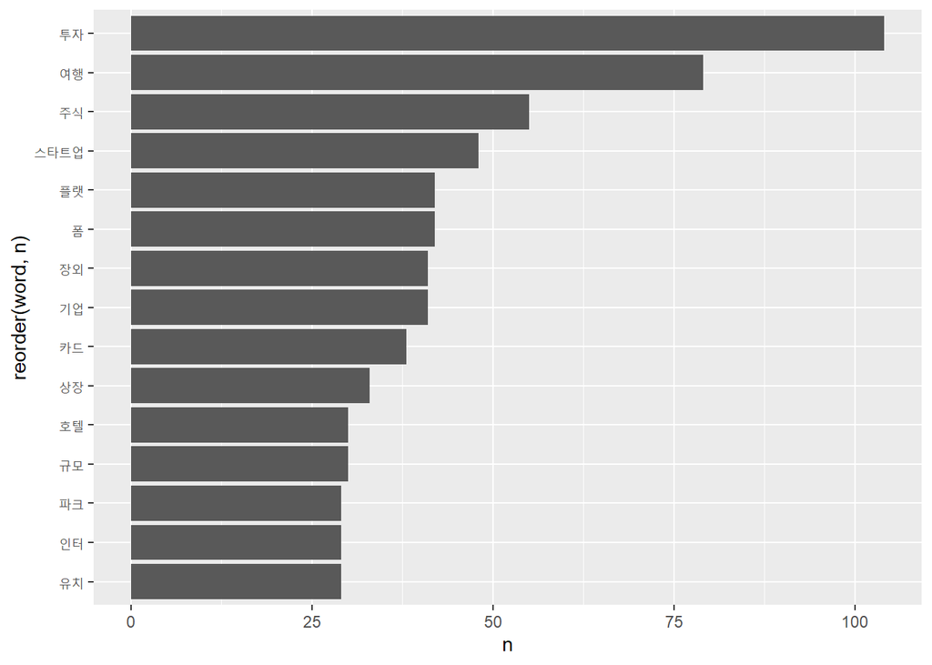

```r
yanolja_total <- yanolja_tk %>%

count(word, sort = T) %>%

slice_max(n, n = 15) %>%

ggplot(aes(x = n,

y = reorder(word, n))) +

geom_col(show.legend = F)

yanolja_total
```

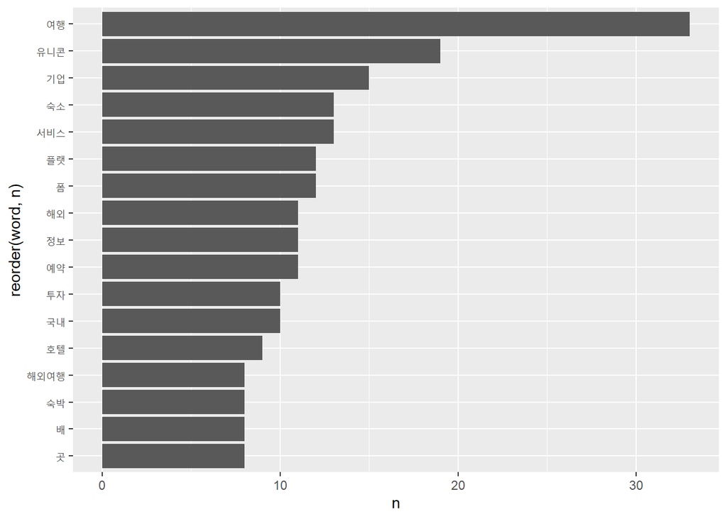

```r
hah_total <- hah_tk %>%

count(word, sort = T) %>%

slice_max(n, n = 15) %>%

ggplot(aes(x = n,

y = reorder(word, n))) +

geom_col(show.legend = F)

hah_total
```

#### 2) 상대빈도(코드 수정중)

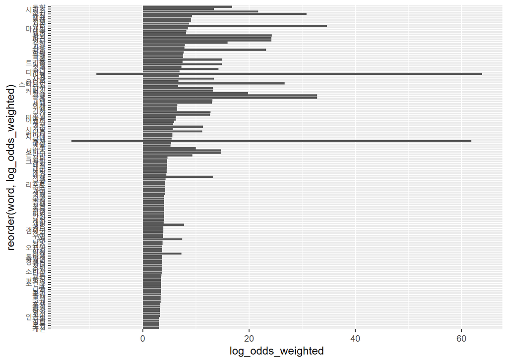

```r
# 언론사별 10개 상위 빈도 단어
yanolja_tk %>%

count(언론사, word) %>%

bind_log_odds(set = 언론사, feature = word, n = n) %>%

group_by(언론사) %>%

slice_max(abs(log_odds_weighted), n = 10) %>%

ggplot(aes(x = log_odds_weighted, y = reorder(word, log_odds_weighted))) +

geom_col(show.legend = F)
```

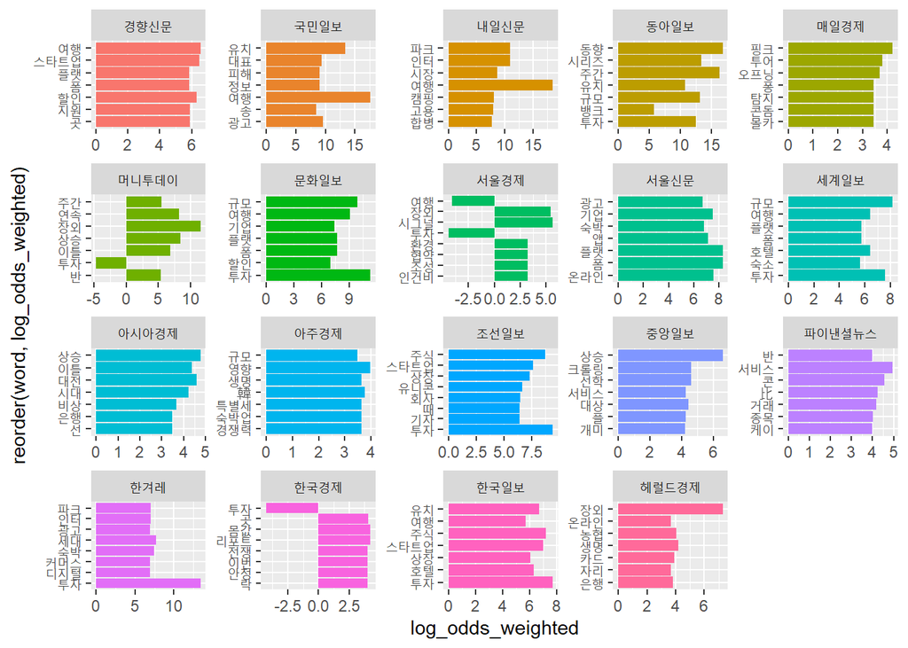

```r
# 언론사별 7개의 상위 빈도 단어
yanolja_tk %>%

count(언론사, word) %>%

bind_log_odds(set = 언론사, feature = word, n = n) %>%

group_by(언론사) %>%

slice_max(abs(log_odds_weighted), n = 7) %>%

ggplot(aes(x = log_odds_weighted, y = reorder(word, log_odds_weighted),

fill = 언론사)) +

geom_col(show.legend = F) +

facet_wrap( ~ 언론사, scales = "free")
```

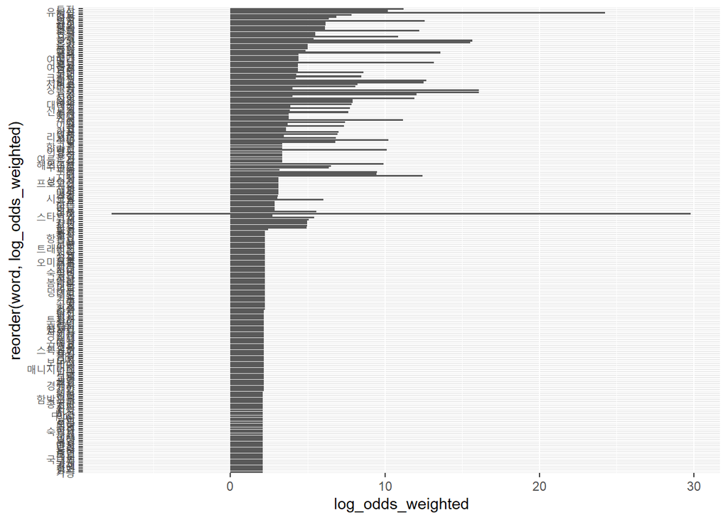

```r
# 언론사별 상위 10개 상대 빈도
hah_tk %>%

count(언론사, word) %>%

bind_log_odds(set = 언론사, feature = word, n = n) %>%

group_by(언론사) %>%

slice_max(abs(log_odds_weighted), n = 10) %>%

ggplot(aes(x = log_odds_weighted, y = reorder(word, log_odds_weighted))) +

geom_col(show.legend = F)
```

### 3. 감정분석

##### 1) 사전 내용 선택

##### 2) 사전 열 이름 변경 및 정제

##### 3) 감정어 분석

```r
#상위 15개 감정어 분석(단어 갯수 2개 이상)
yanolja_senti_df <- yanolja_tk %>%

unnest_tokens(word, 본문, token = pos) %>%

separate(col = word, into = c("word", "morph"), sep = "/" ) %>%

inner_join(knu_dic_df) %>%

count(word, sScore, sort = T) %>%

filter(str_length(word) > 1) %>%

mutate(word = reorder(word, n)) %>%

slice_head(n = 15)
```

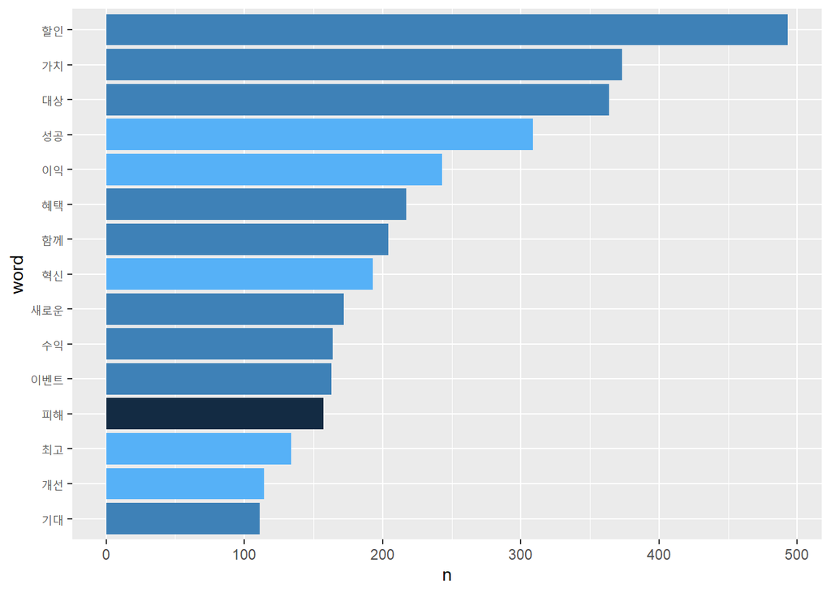

```r
#감정어 그래프
yanolja_senti_df %>%

ggplot()+

geom_col(aes(n, word, fill = sScore), show.legend = F)
```

```r
#감정 분석 점수
yanolja_tk %>%

unnest_tokens(word, 본문) %>%

left_join(knu_dic_df) %>%

mutate(sScore = ifelse(is.na(sScore), 0, sScore)) %>%

arrange(sScore)
```

```
## # A tidytable: 219,929 x 5
##    언론사   URL                                               word  pos   sScore
##    <chr>    <chr>                                             <chr> <chr>  <dbl>
##  1 동아일보 https://www.donga.com/news/article/all/20220907/~ 힘들  nng       -2
##  2 동아일보 https://www.donga.com/news/article/all/20220907/~ 힘들  nng       -2
##  3 동아일보 https://www.donga.com/news/article/all/20220907/~ 힘들  nng       -2
##  4 동아일보 https://www.donga.com/news/article/all/20220907/~ 힘들  nng       -2
##  5 동아일보 https://www.donga.com/news/article/all/20220907/~ 힘들  nng       -2
##  6 동아일보 https://www.donga.com/news/article/all/20220907/~ 힘들  nng       -2
##  7 동아일보 https://www.donga.com/news/article/all/20220907/~ 힘들  nng       -2
##  8 동아일보 https://www.donga.com/news/article/all/20220907/~ 힘들  nng       -2
##  9 동아일보 https://www.donga.com/news/article/all/20220907/~ 힘들  nng       -2
## 10 동아일보 https://www.donga.com/news/article/all/20220907/~ 힘들  nng       -2
## # ... with 219,919 more rows
```

```r
#긍정 부정 단어 갯수
yanolja_tk %>%

unnest_tokens(word, 본문) %>%

left_join(knu_dic_df) %>%

mutate(sScore = ifelse(sScore >= 1, "긍정", ifelse(sScore <= -1, "부정", "중립"))) %>%

count(sScore)
```

```
## # A tidytable: 4 x 2
##   sScore      n
##   <chr>   <int>
## 1 긍정     2723
## 2 부정      737
## 3 중립       52
## 4 <NA>   216417
```

```r
# 감정 점수
yanolja_tk %>%

unnest_tokens(word, 본문) %>%

left_join(knu_dic_df) %>%

mutate(sScore = ifelse(is.na(sScore), 0, sScore)) %>%

summarise(emotion = sum(sScore))
```

```
##   emotion
## 1    2479
```

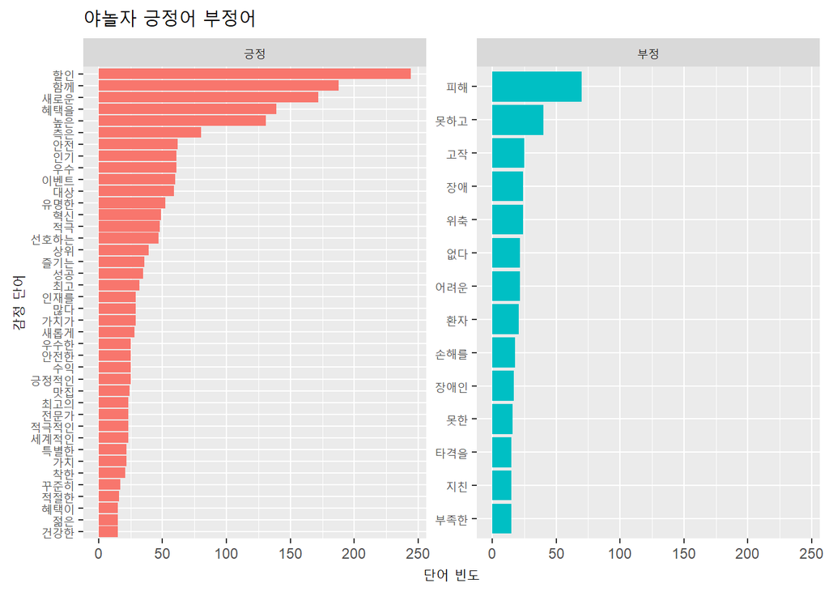

```r
yanolja_tk %>%

unnest_tokens(word, 본문) %>%

inner_join(knu_dic_df) %>%

mutate(emotion = ifelse(sScore > 0, "긍정", ifelse(sScore < 0, "부정", "중립"))) %>%

filter(emotion != "중립") %>%

count(word, emotion, sort = T) %>%

mutate(word = reorder(word, n)) %>%

filter(str_length(word) > 1) %>%

top_n(50) %>%

ggplot(aes(word, n, fill = emotion)) +

geom_col(show.legend = FALSE) +

facet_wrap(~emotion, scales = "free_y") +

labs(y = "단어 빈도", x = "감정 단어", title = "야놀자 긍정어 부정어") +

coord_flip()
```

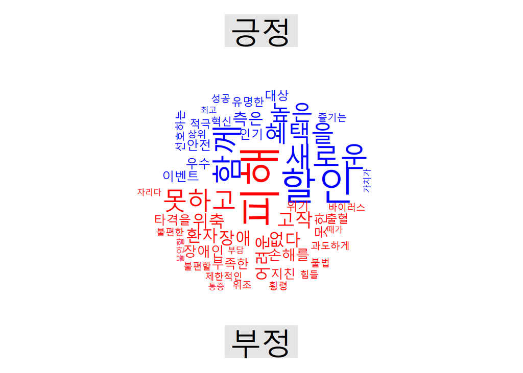

```r
yanolja_tk %>%

unnest_tokens(word, 본문) %>%

inner_join(knu_dic_df) %>%

mutate(emotion = ifelse(sScore > 0, "긍정", ifelse(sScore < 0, "부정", "중립"))) %>%

filter(emotion != "중립") %>%

count(word, emotion, sort = T) %>%

filter(str_length(word) > 1) %>%

reshape2::acast(word ~ emotion, value.var = "n", fill = 0) %>%

comparison.cloud(colors = c("blue", "red"), max.words = 50)
```

```r
#상위 15개 감정어 분석(단어 갯수 2개 이상)

hah_senti_df <- hah_tk %>%

unnest_tokens(word, 본문, token = pos) %>%

separate(col = word, into = c("word", "morph"), sep = "/" ) %>%

inner_join(knu_dic_df) %>%

count(word, sScore, sort = T) %>%

filter(str_length(word) > 1) %>%

mutate(word = reorder(word, n)) %>%

slice_head(n = 15)
```

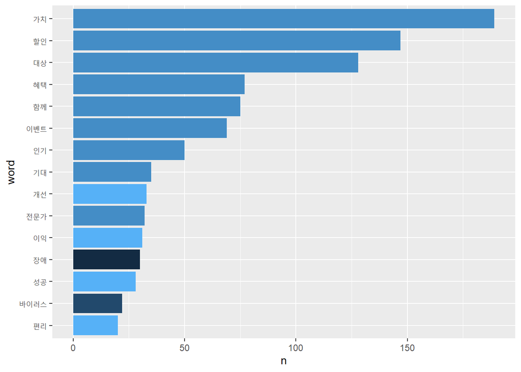

```r
#감정어 그래프

hah_senti_df %>%

ggplot()+

geom_col(aes(n, word, fill = sScore), show.legend = F)
```

```r
#감정 분석 점수
hah_tk %>%

unnest_tokens(word, 본문) %>%

left_join(knu_dic_df) %>%

mutate(sScore = ifelse(is.na(sScore), 0, sScore)) %>%

arrange(sScore)
```

```
## # A tidytable: 44,206 x 5
##    언론사   URL                                               word  pos   sScore
##    <chr>    <chr>                                             <chr> <chr>  <dbl>
##  1 서울신문 http://www.seoul.co.kr/news/newsView.php?id=2022~ 장애~ nng       -2
##  2 서울신문 http://www.seoul.co.kr/news/newsView.php?id=2022~ 장애~ nng       -2
##  3 서울신문 http://www.seoul.co.kr/news/newsView.php?id=2022~ 장애~ nng       -2
##  4 서울신문 http://www.seoul.co.kr/news/newsView.php?id=2022~ 장애~ nng       -2
##  5 서울신문 http://www.seoul.co.kr/news/newsView.php?id=2022~ 장애~ nng       -2
##  6 서울신문 http://www.seoul.co.kr/news/newsView.php?id=2022~ 장애~ nng       -2
##  7 서울신문 http://www.seoul.co.kr/news/newsView.php?id=2022~ 장애~ nng       -2
##  8 서울신문 http://www.seoul.co.kr/news/newsView.php?id=2022~ 장애~ nng       -2
##  9 서울신문 http://www.seoul.co.kr/news/newsView.php?id=2022~ 장애~ nng       -2
## 10 매일경제 http://news.mk.co.kr/newsRead.php?no=758289&year~ 불황  nng       -2
## # ... with 44,196 more rows
```

```r
#긍정 부정 단어 갯수

hah_tk %>%

unnest_tokens(word, 본문) %>%

left_join(knu_dic_df) %>%

mutate(sScore = ifelse(sScore >= 1, "긍정", ifelse(sScore <= -1, "부정", "중립"))) %>%

count(sScore)
```

```
## # A tidytable: 4 x 2
##   sScore     n
##   <chr>  <int>
## 1 긍정     730
## 2 부정     147
## 3 중립      18
## 4 <NA>   43311
```

```r
#감정 점수

hah_tk %>%

unnest_tokens(word, 본문) %>%

left_join(knu_dic_df) %>%

mutate(sScore = ifelse(is.na(sScore), 0, sScore)) %>%

summarise(emotion = sum(sScore))
```

```
##   emotion
## 1     669
```

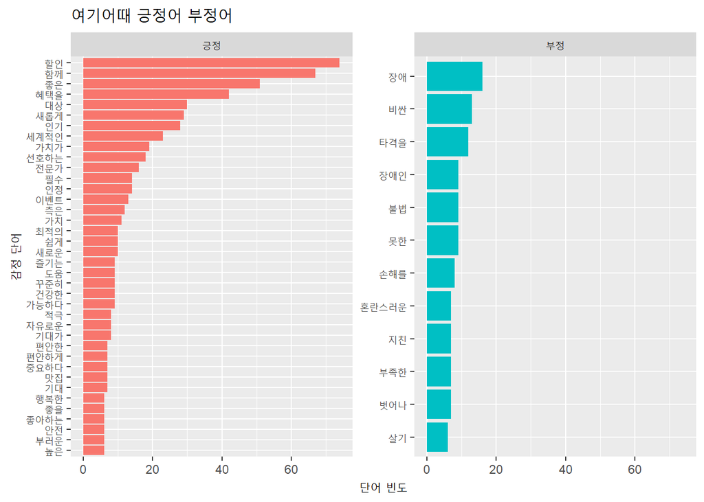

```r
hah_tk %>%

unnest_tokens(word, 본문) %>%

inner_join(knu_dic_df) %>%

mutate(emotion = ifelse(sScore > 0, "긍정", ifelse(sScore < 0, "부정", "중립"))) %>%

filter(emotion != "중립") %>%

count(word, emotion, sort = T) %>%

mutate(word = reorder(word, n)) %>%

filter(str_length(word) > 1) %>%

top_n(50) %>%

ggplot(aes(word, n, fill = emotion)) +

geom_col(show.legend = FALSE) +

facet_wrap(~emotion, scales = "free_y") +

labs(y = "단어 빈도", x = "감정 단어", title = "여기어때 긍정어 부정어") +

coord_flip()
```

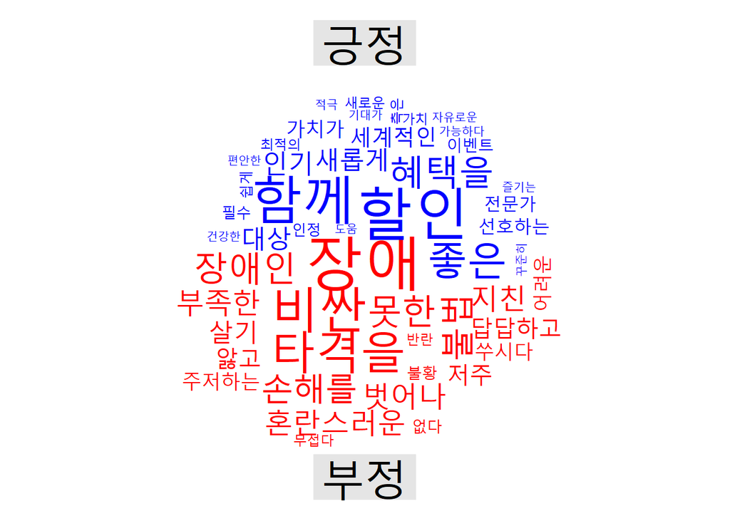

```r
hah_tk %>%

unnest_tokens(word, 본문) %>%

inner_join(knu_dic_df) %>%

mutate(emotion = ifelse(sScore > 0, "긍정", ifelse(sScore < 0, "부정", "중립"))) %>%

filter(emotion != "중립") %>%

count(word, emotion, sort = T) %>%

filter(str_length(word) > 1) %>%

reshape2::acast(word ~ emotion, value.var = "n", fill = 0) %>%

comparison.cloud(colors = c("blue", "red"), max.words = 50)
```

### 4. 주제모형

모형 구축을 위해 기준점이 되는 자료 열 “press”, “cat” 등을 새롭게 불러와 자료를 수집하고

수집한 기사의 중복 기사를 삭제하고 기사별 열 번호를 기입하여 분석에 용의하게 정제했다.

다양한 언론사를 야당지와 여당지로 추가 분류하였고 속하지 않은 언론사는 여당지로 분류하였다.

##### 1) 모델링을 위한 자료 수집

##### 2) 자료 정제

```r
yanolja_sub2 <- yanolja_sub %>%

distinct(제목, .keep_all = T) %>%

mutate(ID = factor(row_number())) %>%

mutate(week = week(ymd(일자))) %>%

unite(제목, 본문, col = "text", sep = " ") %>%

mutate(text = str_squish(text)) %>%

mutate(press = case_when(

언론사 == "조선일보" ~ "야당지",

언론사 == "중앙일보" ~ "야당지",

언론사 == "동앙일보" ~ "야당지",

언론사 == "국민일보" ~ "야당지",

언론사 == "문화일보" ~ "야당지",

언론사 == "한국경제" ~ "야당지",

언론사 == "경향신문" ~ "여당지",

TRUE ~ "여당지") ) %>%

separate(cat, sep = ">", into = c("cat", "cat2")) %>%

select(-cat2) %>%

mutate(catSoc = case_when( cat == "경제" ~ "경제면",
                           cat == "문화" ~ "경제면",
                           TRUE ~ "비경제면") )

#주제별 갯수
yanolja_sub2 %>% count(cat, sort = T)
```

```
## # A tibble: 7 x 2
##   cat         n
##   <chr>   <int>
## 1 경제      475
## 2 IT_과학   133
## 3 문화       88
## 4 사회       25
## 5 지역       20
## 6 국제        2
## 7 정치        2
```

```r
hah_sub2 <- hah_sub %>%

distinct(제목, .keep_all = T) %>%

mutate(ID = factor(row_number())) %>%

mutate(week = week(ymd(일자))) %>%

unite(제목, 본문, col = "text", sep = " ") %>%

mutate(text = str_squish(text)) %>%

mutate(press = case_when(

언론사 == "조선일보" ~ "야당지",

언론사 == "중앙일보" ~ "야당지",

언론사 == "동앙일보" ~ "야당지",

언론사 == "국민일보" ~ "야당지",

언론사 == "문화일보" ~ "야당지",

언론사 == "한국경제" ~ "야당지",

언론사 == "경향신문" ~ "여당지",

TRUE ~ "여당지") ) %>%

separate(cat, sep = ">", into = c("cat", "cat2")) %>%

select(-cat2) %>%

mutate(catSoc = case_when(cat == "경제" ~ "경제면",
                          cat == "문화" ~ "경제면",
                          TRUE ~ "비경제면") )

#여기어때 주제별 갯수
hah_sub2 %>% count(cat, sort = T)
```

```
## # A tibble: 6 x 2
##   cat         n
##   <chr>   <int>
## 1 경제       85
## 2 IT_과학    34
## 3 문화       25
## 4 사회        6
## 5 지역        4
## 6 정치        1
```

##### 3) 토큰화

##### 4) stm 말뭉치

```r
processed_yanol <- yanolja_C %>%
  textProcessor(documents = yanolja_C$text2,
                metadata = .,
                wordLengths = c(2, Inf))
```

```
## Building corpus...
## Converting to Lower Case...
## Removing punctuation...
## Removing stopwords...
## Removing numbers...
## Stemming...
## Creating Output...
```

```r
out_yanol <- prepDocuments(processed_yanol$documents,
                           processed_yanol$vocab,
                           processed_yanol$meta,
                           lower.thresh = 0)

summary(out_yanol)
```

```
##                Length Class      Mode
## documents        745  -none-     list
## vocab          18983  -none-     character
## meta              10  data.frame list
## words.removed      0  -none-     character
## docs.removed       0  -none-     NULL
## tokens.removed     1  -none-     numeric
## wordcounts     18983  -none-     numeric
```

```r
# 모형구축을 위한 객체 저장
docs_yanol <- out_yanol$documents

vocab_yanol <- out_yanol$vocab

meta_yanol <- out_yanol$meta
```

```r
processed_hah <- hah_C %>% textProcessor(documents = hah_C$text2,
                                         metadata = .,
                                         wordLengths = c(2, Inf))
```

```
## Building corpus...
## Converting to Lower Case...
## Removing punctuation...
## Removing stopwords...
## Removing numbers...
## Stemming...
## Creating Output...
```

```r
out_hah <-prepDocuments(processed_hah$documents,
                        processed_hah$vocab,
                        processed_hah$meta,
                        lower.thresh = 0)

# 모형구축을 위한 객체 할당
summary(out_hah)
```

```
##                Length Class      Mode
## documents       155   -none-     list
## vocab          5132   -none-     character
## meta             10   data.frame list
## words.removed     0   -none-     character
## docs.removed      0   -none-     NULL
## tokens.removed    1   -none-     numeric
## wordcounts     5132   -none-     numeric
```

```r
docs_hah <- out_hah$documents

vocab_hah <- out_hah$vocab

meta_hah <- out_hah$meta
```

##### 5) 공변인 분석

##### 6) 주제 이름 짓기

```r
labelTopics(meta_fit_yanol)
```

```
## Topic 1 Top Words:
##       Highest Prob: 투자, 유치, 스타트업, 서비스, 규모, 대표, 플랫폼
##       FREX: 디지코, 블루홀, it동아, 강국, 주간투자동향, kt그룹, 마루
##       Lift: bnk벤처투자, brv, brv캐피탈, ccaa, cctv, dr센터, es인베스터
##       Score: 시리즈a, 디지코, 동아닷컴, 투자, kt, nft, 블루홀
## Topic 2 Top Words:
##       Highest Prob: 야놀자, 여행, 상품, 할인, 숙박, 이용, 예약
##       FREX: 크롤링, 열차, 무죄, 식품몰, 대법원, 침입, 최종혜택
##       Lift: adult, busan, t맵, vat, 가맹숙박업체, 가전제품몰, 강릉동해
##       Score: 크롤링, 서버, 할인, 숙소, 무죄, 혐의, 열차
## Topic 3 Top Words:
##       Highest Prob: 인터파크, 인수, 큐텐, 대표, 티몬, 서울, 지분
##       FREX: 큐텐, 오전시, 순방, 콘돔, 노르웨이, 큐익스프레스, 차관
##       Lift: fnc인베스트먼트, knc뮤직, pif, 가방, 경업, 구속, 국무
##       Score: 큐텐, 오전시, 순방, 여사, 노르웨이, 콘돔, 차관
## Topic 4 Top Words:
##       Highest Prob: 광고, 송해, 야놀자, 마케팅, 강호동, 영상, 플랫폼
##       FREX: 송해, 강호동, gnm홀딩스, 고인, 그랑몬스터, 선생, mc
##       Lift: 건축, 광희, 빠니보틀, 소스메이커스, 야영장, 영덕, 우영우
##       Score: 송해, 강호동, 광고, gnm홀딩스, 고인, 그랑몬스터, 선생
## Topic 5 Top Words:
##       Highest Prob: 대비, 매출, 여행, 야놀자, 전년, 증가, 할인
##       FREX: id, 예약률, 스탬프, 티빙, 니콘내콘, 수영복, 농협카드
##       Lift: 니콘내콘, 수영복, ak, asp, cdo, dighti, dlf
##       Score: 스탬프, 할인, 케이뱅크, id, 숙소, 연휴, 호텔
## Topic 6 Top Words:
##       Highest Prob: 상장, 기업, 시장, 하락, 호가, 투자, 야놀자
##       FREX: 호가, 반등, 현대오일뱅크, 현대엔지니어링, 계열주, 남북경협주, 장외종목
##       Lift: 계열주, 남북경협주, 장외종목, 주가변동, acs브라이트, a등급, bcg
##       Score: 호가, 하락, 종목, 소폭, 상장, 최저가, 매도
## Topic 7 Top Words:
##       Highest Prob: 플랫폼, 근무, 대표, 기업, 서비스, 회사, 야놀자
##       FREX: 연봉, 근무제, 필라이즈, 슬랙, 캐치테이블, 분당, 우테코
##       Lift: abli, ab동, agoda, ai천재, allin, analyz, a동
##       Score: 재택근무, 워케이션, 연봉, 근무, 오피스, 실패, 사무실
## Topic 8 Top Words:
##       Highest Prob: 기업, 투자, 스타트업, 거래, 시장, 플랫폼, 유니콘
##       FREX: 신보, 판교오피스, 베네피아, 상각, 자이낸스, 딥테크, 기능직
##       Lift: 약정, 자이낸스, academyvisitkorea, access, affirm, afterpay, alloc
##       Score: 종목, 유니콘, 태평양, 주식, 판교, 투자자, 신보
## Topic 9 Top Words:
##       Highest Prob: 여행, 야놀자, 플랫폼, 호텔, 서비스, 시장, 예약
##       FREX: 갤럭시, 도메인, 프립, 사이언스, 카운슬, 아프리카, 정태영
##       Lift: environ, eze, glamor, integr, mlk, technosi, tiger
##       Score: 현대카드, 도메인, plcc, 갤럭시, 호텔, 카운슬, 프립
```

```r
#주제 이름 데이터 프레임에 저장
topic_name_yanol <- tibble(topic = 1:9,
                           name = c("1. 투자",
                                    "2. 여행",
                                    "3. 인터파크 인수",
                                    "4. 마케팅",
                                    "5. 매출",
                                    "6. 주식",
                                    "7. 기업",
                                    "8. 거래",
                                    "9. 야놀자 X 현대카드") )

#주제별 상위 7개 단어목록을 데이터 프레임에 저장
td_beta_yanol <- meta_fit_yanol %>% tidy(matrix = 'beta')

term_topic_name_yanol <- td_beta_yanol %>%

group_by(topic) %>%

slice_max(beta, n = 7) %>%

left_join(topic_name_yanol, by = "topic")
```

```r
labelTopics(meta_fit_hah)
```

```
## Topic 1 Top Words:
##       Highest Prob: 여행, 야놀자, 해외, 상품, 해외여행, 연휴, 코로나
##       FREX: 추석, 웹툰, 명절, 연휴, 쿠팡, 작품, 트래블
##       Lift: 거대, 독자, 라이브, 병원, 월간, 작가, 투톱
##       Score: 연휴, 추석, 웹툰, 광고, 쿠팡, 상품, 투어
## Topic 2 Top Words:
##       Highest Prob: 할인, 여행, 광고, 플랫폼, 이용, 야놀자, 숙박업소
##       FREX: 계약서, 스마트, 오피스, 트래버스, 속초, 표시, 공정위
##       Lift: 인증, ktx, suv, 계약서, 공방, 근거, 네고왕
##       Score: 계약서, 쿠폰, 스마트, 광고, 할인, 발급, 오피스
## Topic 3 Top Words:
##       Highest Prob: 기업, 유니콘, 상반기, 아이지에이웍스, 스타트업, 중기부, 기준
##       FREX: 아이지에이웍스, ungc, 유니콘기업, 반기, 탄생, 이영, 시프트업
##       Lift: cdp, oo서비스, un, 고무적, 권춘택, 당부, 메가존클라우드
##       Score: 유니콘, 아이지에이웍스, 중기부, 장관, ungc, 상반기, 유니콘기업
## Topic 4 Top Words:
##       Highest Prob: 결제, 할인, 대비, 혜택, 전년, 카드, 최대
##       FREX: 현대카드, 보너스, 신용, 캐시백, io, 장애인, 결제
##       Lift: 가전, 골프연습장, 국민카드, 넷플릭스, 사이닝, 식당, 아이콘
##       Score: 결제, 현대카드, 결제금액, 국제선, io, 장애인, 신용
## Topic 5 Top Words:
##       Highest Prob: 예약, 숙소, 여행, 호텔, 숙박, 증가, 해외
##       FREX: 워터파크, 거래액, 예약, 워케이션, 숙소, 성수기, 풀빌라
##       Lift: cvc캐피털파트너스, dog, geek, oh, vacat, work, 가까이
##       Score: 숙소, 워케이션, 호캉스, 환불, 워터파크, 거래액, 건수
## Topic 6 Top Words:
##       Highest Prob: 여행, 호캉스, 상품, 시간, 플랫폼, 설문조사, 세대
##       FREX: 배낭여행, 버킷리스트, 경제력, 전기차, 동대구역, 세대, 설문조사
##       Lift: 단축, 보전, 새해, 아이슬란드, 일회용품, 졸업생, 호캉스족
##       Score: 버킷리스트, 배낭여행, 설문조사, 호캉스, 대학생, 경제력, 관광
## Topic 7 Top Words:
##       Highest Prob: 투자, 기업, 대표, 성장, 플랫폼, 사업, 유치
##       FREX: 미래에셋캐피탈, 신세계까사, pef, jkl파트너스, ib, 투자, 리빙
##       Lift: pef, 가동, 김경모, 뉴비고, 뉴빌리티, 다각, 닷페이스
##       Score: 미래에셋캐피탈, 투자, 신세계까사, 벤처, jkl파트너스, 유니콘, 인수
## Topic 8 Top Words:
##       Highest Prob: 서비스, 항공권, 상품, 원대, 혜택, 할인, 제공
##       FREX: 최종혜택, 베네피아, 모요, 알뜰폰, 요금, 원대, 옥션
##       Lift: e쿠폰, financ, learn, refresh, sk엠앤서비스, well, welllif
##       Score: 최종혜택, 베네피아, 원대, 특가, 새벽, 복지, 모요
## Topic 9 Top Words:
##       Highest Prob: 정보, 야놀자, 대표, 서버, 크롤링, 혐의, 수집
##       FREX: 서버, 크롤링, 혐의, 수집, 무죄, 복제, 위반
##       Lift: api, 검찰, 경쟁관계, 경쟁업체, 공학, 글라스락, 대량
##       Score: 서버, 크롤링, 혐의, 수집, 무죄, 복제, 위반
```

```r
#주제 이름 데이터 프레임에 저장
topic_name_hah <- tibble(topic = 1:9,
                         name = c("1. 여행",
                                  "2. 계약",
                                  "3. 기업",
                                  "4. 할인 해택",
                                  "5. 성수기 예약",
                                  "6. 여행테마",
                                  "7. 투자",
                                  "8. 할인해택",
                                  "9. 범죄") )

#주제별 상위 7개 단어목록을 데이터 프레임에 저장
td_beta_hah <- meta_fit_hah %>% tidy(matrix = 'beta')

term_topic_name_hah <-

  td_beta_hah %>%

  group_by(topic) %>%

  slice_max(beta, n = 7) %>%

  left_join(topic_name_hah, by = "topic")
```

##### 7) 주제별 단어 분포표

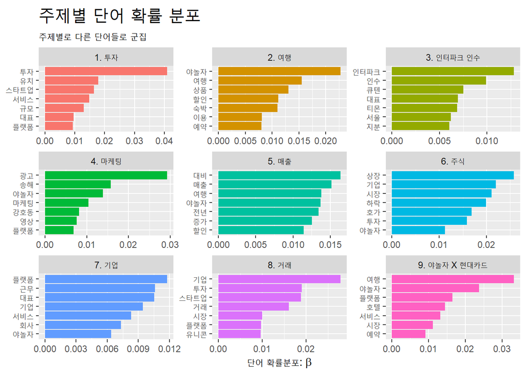

```r
term_topic_name_yanol %>%
  ggplot(aes(x = beta,
             y = reorder_within(term, beta, name),
             fill = name)) +
  geom_col(show.legend = F) +

  facet_wrap(~name, scales = "free") +

  scale_y_reordered() +

  labs(x = expression("단어 확률분포:"~beta), y = NULL,
       title = "주제별 단어 확률 분포",
       subtitle = "주제별로 다른 단어들로 군집") +

  theme(plot.title = element_text(size = 20))
```

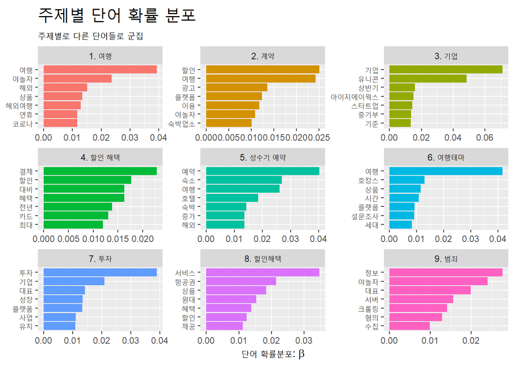

```r
term_topic_name_hah %>%

  ggplot(aes(x = beta,
             y = reorder_within(term, beta, name),
             fill = name)) +

  geom_col(show.legend = F) +

  facet_wrap(~name, scales = "free") +

  scale_y_reordered() +

  labs(x = expression("단어 확률분포:"~beta),
       y = NULL,
       title = "주제별 단어 확률 분포",
       subtitle = "주제별로 다른 단어들로 군집") +

  theme(plot.title = element_text(size = 20))
```

##### 8) 감마를 통한 주제 관련보도 상위 주제어

감마는 주제어의 문서 분포를 확인하기 위해 쓰지만 분석 자료로 사용하지 않고 감마의 평균값을 통하여 주제 관련 보도의 상위 주제어를 파악할 수 있다.

```r
#감마분석
td_gamma_yanol <- meta_fit_yanol %>% tidy(matrix = 'gamma')

#단어분포 자료를 통해 주제별 상위 7개 단어 선정
top_terms_yanol <-

td_beta_yanol %>%

group_by(topic) %>%

slice_max(beta, n = 7) %>%

select(topic, term) %>%

summarise(terms = str_flatten(term, collapse = ","))

top_terms_yanol
```

```
## # A tibble: 9 x 2
##   topic terms
##   <int> <chr>
## 1     1 투자,유치,스타트업,서비스,규모,대표,플랫폼
## 2     2 야놀자,여행,상품,할인,숙박,이용,예약
## 3     3 인터파크,인수,큐텐,대표,티몬,서울,지분
## 4     4 광고,송해,야놀자,마케팅,강호동,영상,플랫폼
## 5     5 대비,매출,여행,야놀자,전년,증가,할인
## 6     6 상장,기업,시장,하락,호가,투자,야놀자
## 7     7 플랫폼,근무,대표,기업,서비스,회사,야놀자
## 8     8 기업,투자,스타트업,거래,시장,플랫폼,유니콘
## 9     9 여행,야놀자,플랫폼,호텔,서비스,시장,예약
```

```r
#주제별 감마 평균 계산
gamma_terms_yanol <-

td_gamma_yanol %>%

group_by(topic) %>%

summarise(gamma = mean(gamma)) %>%

left_join(top_terms_yanol, by = 'topic') %>%

left_join(topic_name_yanol, by = 'topic')

gamma_terms_yanol
```

```
## # A tibble: 9 x 4
##   topic  gamma terms                                      name
##   <int>  <dbl> <chr>                                      <chr>
## 1     1 0.0832 투자,유치,스타트업,서비스,규모,대표,플랫폼 1. 투자
## 2     2 0.171  야놀자,여행,상품,할인,숙박,이용,예약       2. 여행
## 3     3 0.0749 인터파크,인수,큐텐,대표,티몬,서울,지분     3. 인터파크 인수
## 4     4 0.0518 광고,송해,야놀자,마케팅,강호동,영상,플랫폼 4. 마케팅
## 5     5 0.148  대비,매출,여행,야놀자,전년,증가,할인       5. 매출
## 6     6 0.128  상장,기업,시장,하락,호가,투자,야놀자       6. 주식
## 7     7 0.0908 플랫폼,근무,대표,기업,서비스,회사,야놀자   7. 기업
## 8     8 0.126  기업,투자,스타트업,거래,시장,플랫폼,유니콘 8. 거래
## 9     9 0.127  여행,야놀자,플랫폼,호텔,서비스,시장,예약   9. 야놀자 X 현대카드
```

```r
#감마분석
td_gamma_hah <- meta_fit_hah %>% tidy(matrix = 'gamma')

#단어분포 자료를 통해 주제별 상위 7개 단어 선정
top_terms_hah <-

td_beta_hah %>%

group_by(topic) %>%

slice_max(beta, n = 7) %>%

select(topic, term) %>%

summarise(terms = str_flatten(term, collapse = ","))

top_terms_hah
```

```
## # A tibble: 9 x 2
##   topic terms
##   <int> <chr>
## 1     1 여행,야놀자,해외,상품,해외여행,연휴,코로나
## 2     2 할인,여행,광고,플랫폼,이용,야놀자,숙박업소
## 3     3 기업,유니콘,상반기,아이지에이웍스,스타트업,중기부,기준
## 4     4 결제,할인,대비,혜택,전년,카드,최대
## 5     5 예약,숙소,여행,호텔,숙박,증가,해외
## 6     6 여행,호캉스,상품,시간,플랫폼,설문조사,세대
## 7     7 투자,기업,대표,성장,플랫폼,사업,유치
## 8     8 서비스,항공권,상품,원대,혜택,할인,제공
## 9     9 정보,야놀자,대표,서버,크롤링,혐의,수집
```

```r
#주제별 감마 평균 계산
gamma_terms_hah <-

td_gamma_hah %>%

group_by(topic) %>%

summarise(gamma = mean(gamma)) %>%

left_join(top_terms_hah, by = 'topic') %>%

left_join(topic_name_hah, by = 'topic')

gamma_terms_hah
```

```
## # A tibble: 9 x 4
##   topic  gamma terms                                                  name
##   <int>  <dbl> <chr>                                                  <chr>
## 1     1 0.112  여행,야놀자,해외,상품,해외여행,연휴,코로나             1. 여행
## 2     2 0.134  할인,여행,광고,플랫폼,이용,야놀자,숙박업소             2. 계약
## 3     3 0.105  기업,유니콘,상반기,아이지에이웍스,스타트업,중기부,기준 3. 기업
## 4     4 0.0626 결제,할인,대비,혜택,전년,카드,최대                     4. 할인 ~
## 5     5 0.165  예약,숙소,여행,호텔,숙박,증가,해외                     5. 성수기~
## 6     6 0.0847 여행,호캉스,상품,시간,플랫폼,설문조사,세대             6. 여행테~
## 7     7 0.120  투자,기업,대표,성장,플랫폼,사업,유치                   7. 투자
## 8     8 0.0991 서비스,항공권,상품,원대,혜택,할인,제공                 8. 할인해~
## 9     9 0.118  정보,야놀자,대표,서버,크롤링,혐의,수집                 9. 범죄
```

##### 9) 상위 주제어 그래프

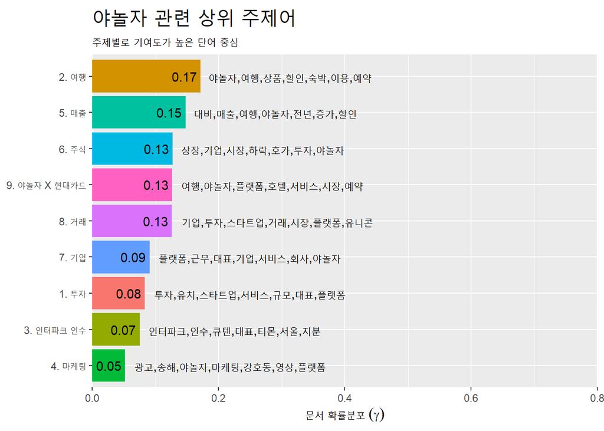

```r
gamma_terms_yanol %>%

  ggplot(aes(x = gamma, y = reorder(name, gamma), fill = name)) +

  geom_col(show.legend = F) +

  geom_text(aes(label = round(gamma, 2)),
            hjust = 1.15) +

  geom_text(aes(label = terms),
            hjust = -0.05) +

  scale_x_continuous(expand = c(0, 0),
                     limit = c(0, .8)) +

  labs(x = expression("문서 확률분포"~(gamma)),
       y = NULL,
       title = "야놀자 관련 상위 주제어",
       subtitle = "주제별로 기여도가 높은 단어 중심") +

  theme(plot.title = element_text(size = 20))
```

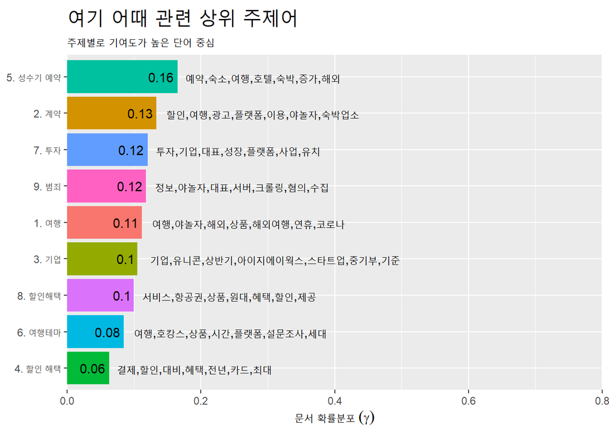

```r
gamma_terms_hah %>%

ggplot(aes(x = gamma, y = reorder(name, gamma), fill = name)) +

geom_col(show.legend = F) +

geom_text(aes(label = round(gamma, 2)),
          hjust = 1.15) +

geom_text(aes(label = terms),
          hjust = -0.05) +

scale_x_continuous(expand = c(0, 0),
                   limit = c(0, .8)) +

labs(x = expression("문서 확률분포"~(gamma)),
     y = NULL,
     title = "여기 어때 관련 상위 주제어",
     subtitle = "주제별로 기여도가 높은 단어 중심") +

theme(plot.title = element_text(size = 20))
```